# Question

A thief is stealing xots and yivs. Each xot has a mass of 10 kilograms and a volume of 15 liters. Each yiv has a mass of 16 kilograms and a volume of 12 liters. The thief can carry a maximum mass of 160 kilograms and a maximum volume of 180 liters. The profit from each xot is $4.3 and the profit from each yiv is $4.57.

For your convenience, those numbers are organized in the table below.

| attribute | xot | yiv | capacity |
| --- | --- | --- | --- |
| mass (kg) | 10 | 16 | 160 |
| volume (L) | 15 | 12 | 180 |
| profit ($) | 4.30 | 4.57 | $\infty$ |

What is the maximum profit the thief can produce? *(In dollars.)*

# Solution

This is an example of [linear programming](https://en.wikipedia.org/wiki/Linear_programming).

Define $x$ as number of xots and $y$ as number of yivs. Write the constraints as inequalities.

- Mass constraint: $10x+16y \le 160$
- Volume constraint: $15x+12y \le 180$

We can assume that optimal profit will occur at a boundary, so we can just consider the equations.
$$10x+16y =
160$$
$$15x+12y = 180$$

If either equation has coefficients that all share a common factor, we can simplify by dividing both sides by the greatest common factor:

$$5x+8y = 80$$
$$5x+4y = 60$$

We need to find the $x$ intercepts and the $y$ intercepts.

To find the $x$-intercepts, set $y$ to 0.

- The $x$-intercept of the mass constraint:
  $$5x_{\text{int}1}+(8)(0) = 80$$
  $$5x_{\text{int}1} = 80$$
  $$x_{\text{int}1} = \frac{80}{5} = 16$$
- The $x$-intercept of the volume constraint:

$$5x_{\text{int}2}+(4)(0) = 60$$
$$5x_{\text{int}2} = 60$$
$$x_{\text{int}2} = \frac{60}{5} = 12$$

To find the $y$-intercepts, set $x$ to 0.

- The $y$-intercept of the mass constraint:
  $$(5)(0)+(8)(y_{\text{int1}}) =
  80$$
  $$8y_{\text{int}1} = 80$$
  $$y_{\text{int}1} = \frac{80}{8} =
  10$$
- The $y$-intercept of the volume constraint:

$$(5)(0)+(4)y_{\text{int2}} = 60$$
$$4y_{\text{int}2} = 60$$
$$y_{\text{int}2} = \frac{60}{4} = 15$$

To find the intersection of the constraints, I would recommend elimination. Multiply the equations to have matching coefficients for $y$ terms.

$$5x + 8y = 80$$
$$10x + 8y = 120$$
Subtract equations.

$$5x + (0)y = 40$$

Simplify.

$$5x = 40$$

Divide by 5.

$$x = 8$$

Plug $x = 8$ into the first equation. Solve for $y$.

$$(5)(8)+8y = 80$$
$$40+8y = 80$$
$$8y = 40$$
$$y =
5$$

So, the intersection occurs at $(8,\,5)$.

You can plot the boundaries and shade the [feasible region](https://en.wikipedia.org/wiki/Feasible_region).

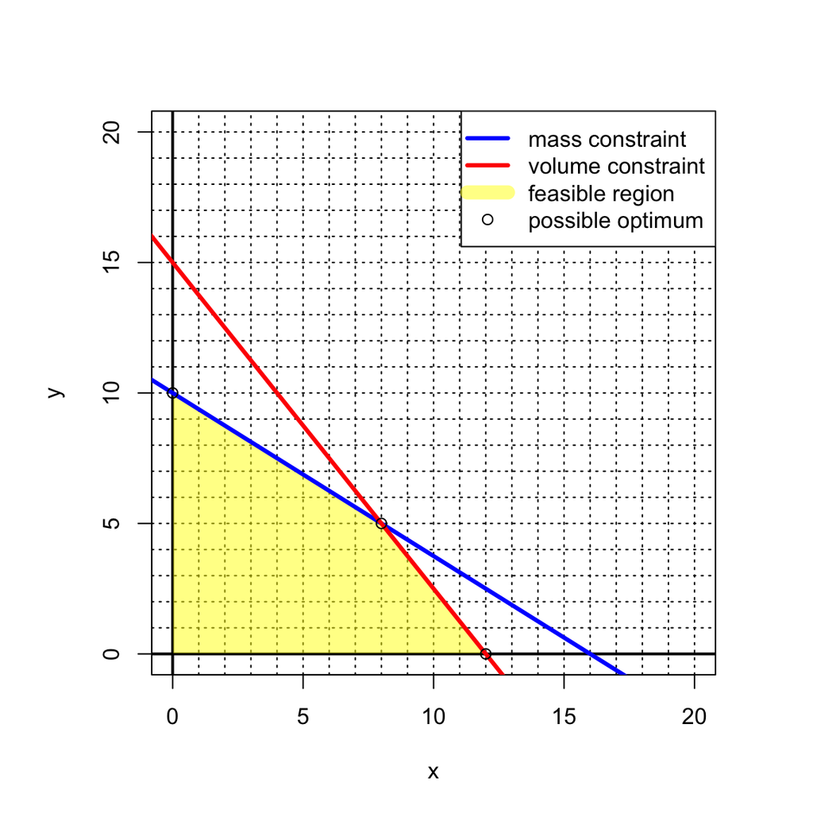

The maximum profit could occur at $(0,10)$ or $(8,5)$ or $(12,0)$.

Find those profits, using $P(x,y)=4.3x+4.57y$.

$$P(0,10)=(4.3)(0)+(4.57)(10) =
45.7$$
$$P(8,5)=(4.3)(8)+(4.57)(5) =
57.25$$
$$P(12,0)=(4.3)(12)+(4.57)(0)
= 51.6$$

So, the maximum profit is $57.25.

It might help to visualize this in 3D, with xots, yivs, and profit on the 3 axes. Sorry, I was not able to make a 3D plot show up here. But, we can add a third “dimension” by using a color ramp for profit. You can see that since our profit function is linear in $x$ and linear in $y$, the profit grows linearly as either xots or yivs are added. Another useful concept is an [isoprofit line](https://www.youtube.com/watch?v=QkIrNqiJZw4), which shows all the possible combinations of xots and yivs that would generate the same profit (see [contour lines](https://en.wikipedia.org/wiki/Contour_line)).

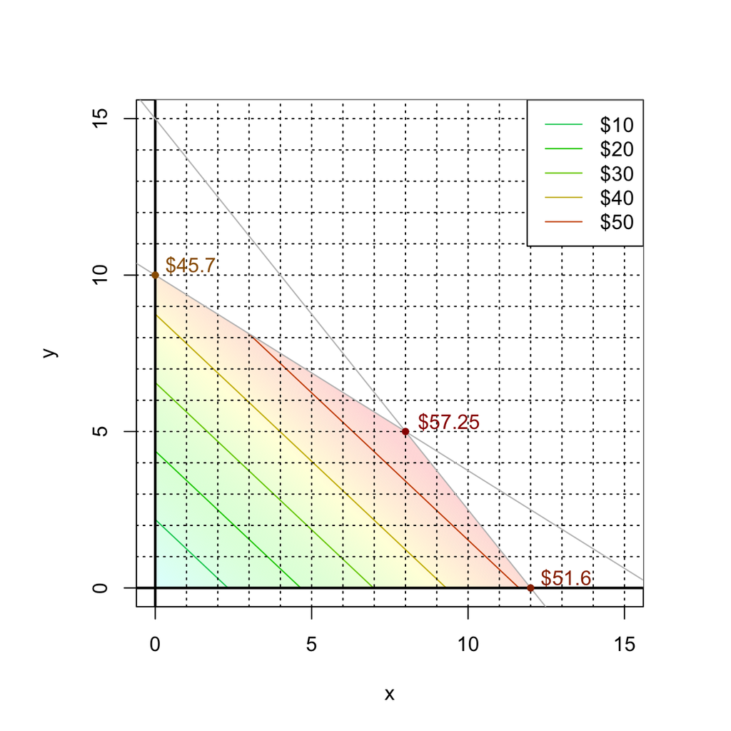

# Meta-information

extype: num exsolution: 57.25 extol: 0.01 exname: opt_thief